# PA1_template

ZTHM

November 15, 2015

```r
library(knitr)
opts_chunk$set(echo = TRUE, results = 'hold')
```

```r
#load the data
library(knitr)
library(data.table)
```

```r
library(plyr)
library(ggplot2)
library(scales)
library(RCurl)
library(lattice)
```

Loading and preprocessing the data

Show any code that is needed to

1. Load the data (i.e. read.csv())

```r
activity <- read.csv('activity.csv', header = TRUE, sep = ",",
                  colClasses=c("numeric", "character", "numeric"))
head(activity)
```

```
##   steps       date interval
## 1    NA 2012-10-01        0
## 2    NA 2012-10-01        5
## 3    NA 2012-10-01       10
## 4    NA 2012-10-01       15
## 5    NA 2012-10-01       20
## 6    NA 2012-10-01       25
```

# 2.Process/transform the data (if necessary) into a format suitable for your analysis

```r
activity$date <- as.Date(activity$date, format = "%Y-%m-%d")
activity$interval <- as.factor(activity$interval)
str(activity)
```

```
## 'data.frame':    17568 obs. of  3 variables:
##  $ steps   : num  NA NA NA NA NA NA NA NA NA NA ...
##  $ date    : Date, format: "2012-10-01" "2012-10-01" ...
##  $ interval: Factor w/ 288 levels "0","5","10","15",..: 1 2 3 4 5 6 7 8 9 10 ...
```

# What is mean total number of steps taken per day?

For this part of the assignment, you can ignore the missing values in the dataset. 1.) Calculate the total number of steps taken per day

```r
steps_per_day <- aggregate(steps ~ date, activity, sum)
colnames(steps_per_day) <- c("date","steps")
head(steps_per_day)
```

```
##         date steps
## 1 2012-10-02   126
## 2 2012-10-03 11352
## 3 2012-10-04 12116
## 4 2012-10-05 13294
## 5 2012-10-06 15420
## 6 2012-10-07 11015
```

2.)If you do not understand the difference between a histogram and a barplot, research the difference between them. Make a histogram of the total number of steps taken each day

```r
require("dplyr")
```

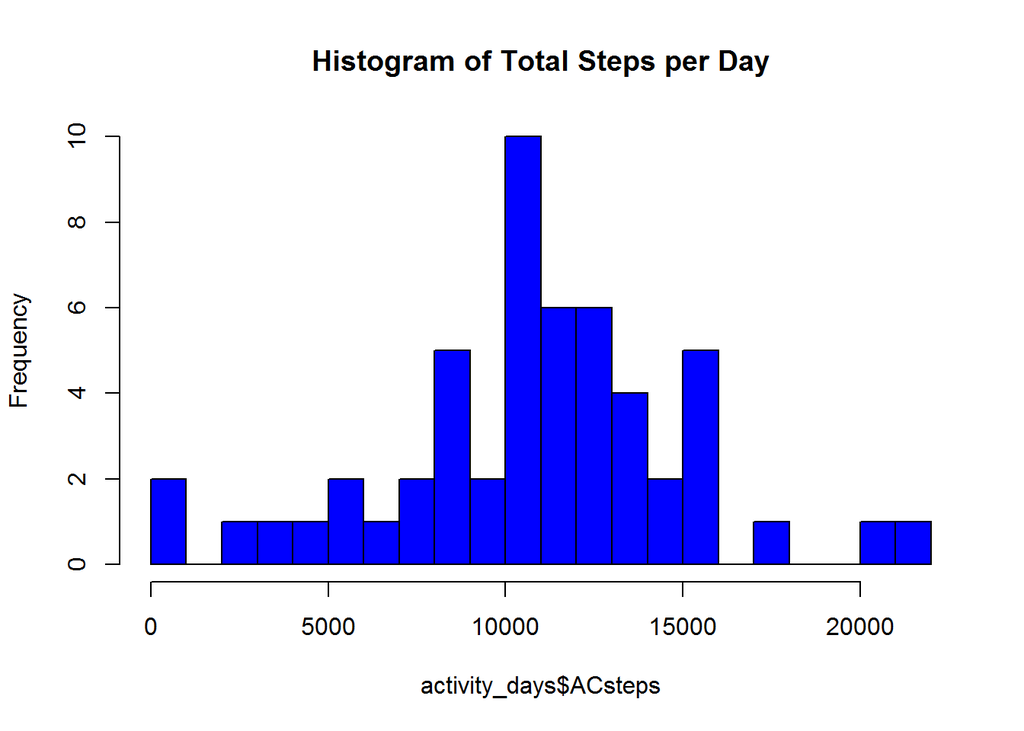

```r
require("ggplot2")

activity_days <- activity %>% group_by(date) %>% summarise(ACsteps = sum(steps))
hist(activity_days$ACsteps, breaks = 25, col="blue", main = "Histogram of Total Steps per Day")
```

3.) Calculate and report the mean and median of the total number of steps taken per day

```r
summary(steps_per_day)
```

```
##       date                steps
##  Min.   :2012-10-02   Min.   :   41
##  1st Qu.:2012-10-16   1st Qu.: 8841
##  Median :2012-10-29   Median :10765
##  Mean   :2012-10-30   Mean   :10766
##  3rd Qu.:2012-11-16   3rd Qu.:13294
##  Max.   :2012-11-29   Max.   :21194
```

Mean of total number of steps per day is 10766, median is 10765. What is the average daily activity pattern? ==================================================

1. Make a time series plot (i.e. type = “l”) of the 5-minute interval (x-axis) and the average number of steps taken, averaged across all days (y-axis)

```r
# Compute the means of steps accross all days for each interval
mean_activity <- aggregate(activity$steps,
                       by=list(activity$interval),
                       FUN=mean,
                       na.rm=TRUE)

# Rename the attributes
names(mean_activity) <- c("interval", "mean")
```

```r
head(mean_activity)
```

```
##   interval      mean
## 1        0 1.7169811
## 2        5 0.3396226
## 3       10 0.1320755
## 4       15 0.1509434
## 5       20 0.0754717
## 6       25 2.0943396
```

Time Series plot

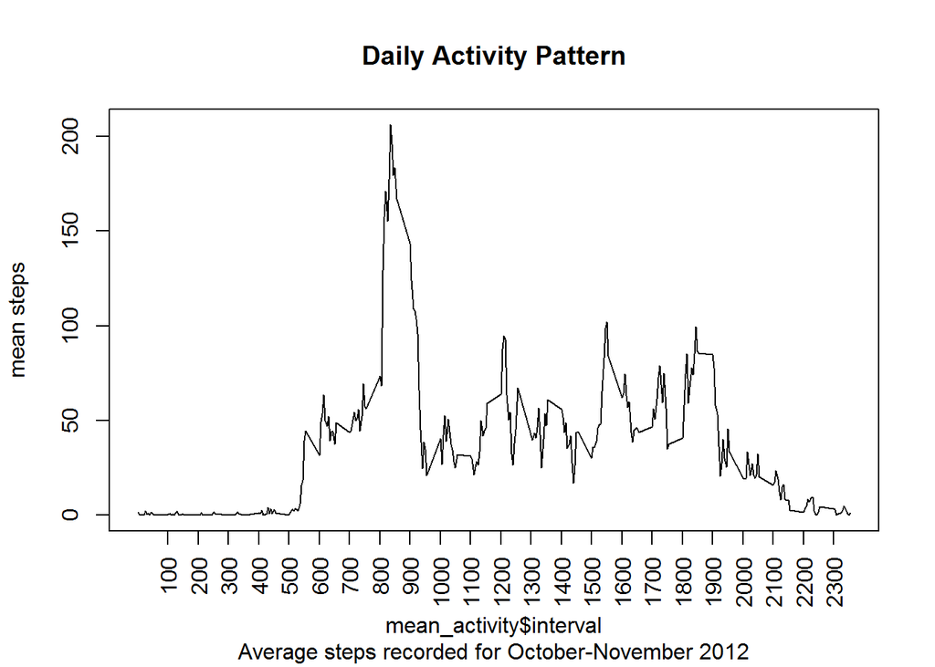

```r
# Compute the time series plot
activity$interval.factor <- as.factor(activity$interval)
mean_activity <- activity  %>% group_by(interval.factor) %>%
  summarise(mean.steps = mean(steps, na.rm =TRUE))

mean_activity$interval <- as.numeric(as.character(mean_activity$interval.factor))
plot(mean_activity$interval, mean_activity $mean.steps, type = "l", xaxt="n",

     ylab = "mean steps", main = "Daily Activity Pattern", sub = "Average steps recorded for October-November 2012")
axis(1, at = seq(100, 2300, by = 100), las = 2)
```

2. Which 5-minute interval, on average across all the days in the dataset, contains the maximum number of steps?

```r
max_steps_interval <- which.max(mean_activity$mean.steps)
print(mean_activity[max_steps_interval,])
```

```
## Source: local data frame [1 x 3]
##
##   interval.factor mean.steps interval
##            (fctr)      (dbl)    (dbl)
## 1             835   206.1698      835
```

# Imputing missing values

Note that there are a number of days/intervals where there are missing values (coded as NA). The presence of missing days may introduce bias into some calculations or summaries of the data.

1. Calculate and report the total number of missing values in the dataset (i.e. the total number of rows with NAs)

```r
sum(is.na(activity$steps))
```

```
## [1] 2304
```

2. Devise a strategy for filling in all of the missing values in the dataset. The strategy does not need to be sophisticated. For example, you could use the mean/median for that day, or the mean for that 5-minute interval, etc.

```r
activity$weekday <- weekdays(as.Date(activity$date))
activity$weekday <- factor(activity$weekday, levels= c("Monday",
    "Tuesday", "Wednesday", "Thursday", "Friday", "Saturday", "Sunday"))
activity_day <- activity %>% group_by(weekday, interval.factor) %>%
  summarise(mean.steps = mean(steps, na.rm =TRUE))
```

3.Create a new dataset that is equal to the original dataset but with the missing data filled in.

```r
activity_impute <- merge(activity, activity_day, by=c("weekday","interval.factor"))
activity_impute$impute.steps <- ifelse(is.na(activity_impute$steps),
                                       activity_impute$mean.steps, activity_impute$steps)

Activity_imputed <- aggregate(steps ~ date, activity_impute, sum)
head(Activity_imputed)
```

```
##         date steps
## 1 2012-10-02   126
## 2 2012-10-03 11352
## 3 2012-10-04 12116
## 4 2012-10-05 13294
## 5 2012-10-06 15420
## 6 2012-10-07 11015
```

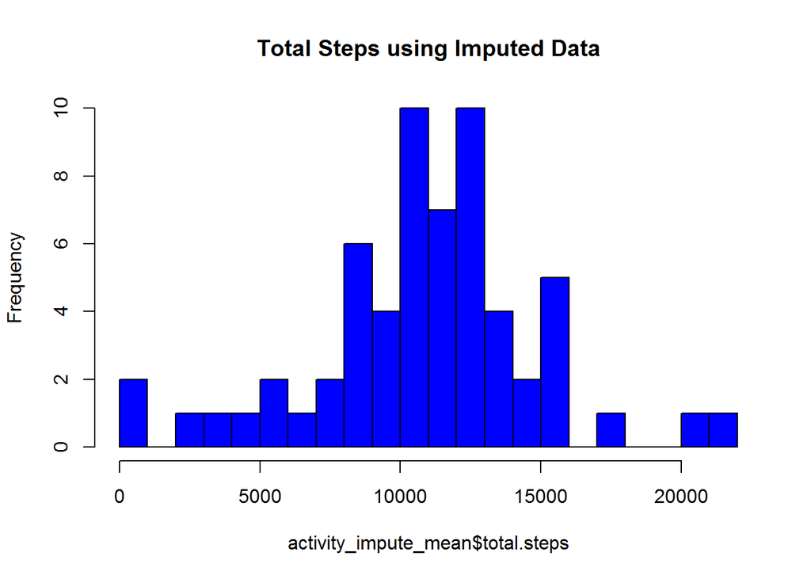

```r
activity_impute_mean <- activity_impute %>% group_by(date) %>%
  summarise(total.steps = sum(impute.steps))
hist(activity_impute_mean$total.steps, breaks = 25,
     col="blue",main = "Total Steps using Imputed Data")
```

Are there differences in activity patterns between weekdays and weekends?

For this part the weekdays() function may be of some help here. Use the dataset with the filled-in missing values for this part.

1. Create a new factor variable in the dataset with two levels - “weekday” and “weekend” indicating whether a given date is a weekday or weekend day.

```r
activity_impute <- activity_impute %>%
  mutate(weekend = ifelse(weekday == "Saturday" | weekday == "Sunday", "weekend", "weekday"))
```

2. Make a panel plot containing a time series plot (i.e. type = “l”) of the 5-minute interval (x-axis) and the average number of steps taken, averaged across all weekday days or weekend days (y-axis). See the README file in the GitHub repository to see an example of what this plot should look like using simulated data.

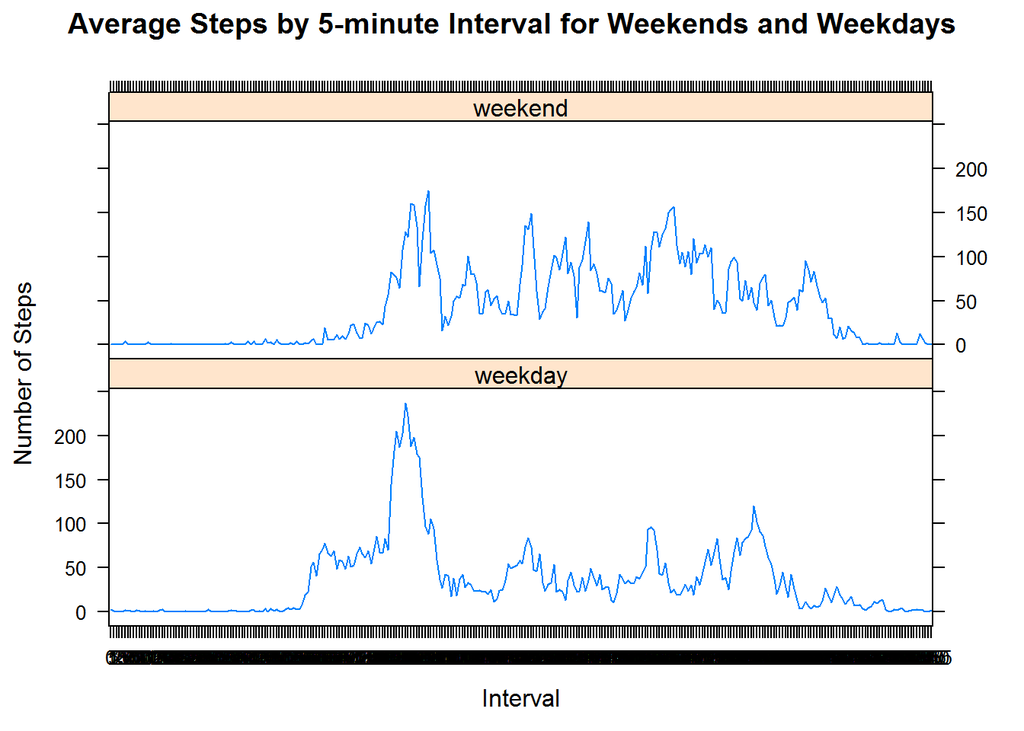

```r
activity_impute_mean <- activity_impute %>% group_by(weekend, interval) %>%
  summarise(mean.steps = mean(impute.steps))
xyplot(mean.steps ~ interval | weekend, data = activity_impute_mean,
       type = "l", layout = c(1,2), xlab = "Interval", ylab = "Number of Steps",
       main = "Average Steps by 5-minute Interval for Weekends and Weekdays")
```